# Loan Prediction

Rohit Dixit

## Problem Statement

Company wants to automate the loan eligibility process (real time) based on customer detail provided while filling online application form. These details are Gender, Marital Status, Education, Number of Dependents, Income, Loan Amount, Credit History and others. To automate this process, they have given a problem to identify the customers segments, those are eligible for loan amount so that they can specifically target these customers. Here they have provided a partial data set.

## Data Glimpse

**Variable** **Description**  
Loan_ID -Unique Loan ID  
Gender -Male/ Female  
Married -Applicant married (Y/N)  
Dependents -Number of dependents  
Education -Applicant Education (Graduate/ Under Graduate)  
Self_Employed -Self employed (Y/N)  
ApplicantIncome -Applicant income  
CoapplicantIncome -Coapplicant income  
LoanAmount -Loan amount in thousands  
Loan_Amount_Term -Term of loan in months  
Credit_History -credit history meets guidelines  
Property_Area -Urban/ Semi Urban/ Rural  
Loan_Status Loan -approved (Y/N)

## R Code

**Importing Library**

```r
library(caret)
```

```r
library(mlbench)
library(ggplot2)
library(ggthemes)
library(plyr)
library(RANN)
library(gridExtra)
```

**Data Importing**

```r
#data<-read.csv(url('https://datahack-prod.s3.ap-south-1.amazonaws.com/train_file/train_u6lujuX_CVtuZ9i.csv'))
train_data <-read.csv("train.csv")
test_data <-read.csv("test.csv")
```

**Data Exploration**

```r
summary(train_data)
```

```
##      Loan_ID       Gender    Married   Dependents        Education
##  LP001002:  1         : 13      :  3     : 15     Graduate    :480
##  LP001003:  1   Female:112   No :213   0 :345     Not Graduate:134
##  LP001005:  1   Male  :489   Yes:398   1 :102
##  LP001006:  1                          2 :101
##  LP001008:  1                          3+: 51
##  LP001011:  1
##  (Other) :608
##  Self_Employed ApplicantIncome CoapplicantIncome   LoanAmount
##     : 32       Min.   :  150   Min.   :    0     Min.   :  9.0
##  No :500       1st Qu.: 2878   1st Qu.:    0     1st Qu.:100.0
##  Yes: 82       Median : 3812   Median : 1188     Median :128.0
##                Mean   : 5403   Mean   : 1621     Mean   :146.4
##                3rd Qu.: 5795   3rd Qu.: 2297     3rd Qu.:168.0
##                Max.   :81000   Max.   :41667     Max.   :700.0
##                                                  NA's   :22
##  Loan_Amount_Term Credit_History     Property_Area Loan_Status
##  Min.   : 12      Min.   :0.0000   Rural    :179   N:192
##  1st Qu.:360      1st Qu.:1.0000   Semiurban:233   Y:422
##  Median :360      Median :1.0000   Urban    :202
##  Mean   :342      Mean   :0.8422
##  3rd Qu.:360      3rd Qu.:1.0000
##  Max.   :480      Max.   :1.0000
##  NA's   :14       NA's   :50
```

```r
summary(test_data)
```

```
##      Loan_ID       Gender    Married   Dependents        Education
##  LP001015:  1         : 11   No :134     : 10     Graduate    :283
##  LP001022:  1   Female: 70   Yes:233   0 :200     Not Graduate: 84
##  LP001031:  1   Male  :286             1 : 58
##  LP001035:  1                          2 : 59
##  LP001051:  1                          3+: 40
##  LP001054:  1
##  (Other) :361
##  Self_Employed ApplicantIncome CoapplicantIncome   LoanAmount
##     : 23       Min.   :    0   Min.   :    0     Min.   : 28.0
##  No :307       1st Qu.: 2864   1st Qu.:    0     1st Qu.:100.2
##  Yes: 37       Median : 3786   Median : 1025     Median :125.0
##                Mean   : 4806   Mean   : 1570     Mean   :136.1
##                3rd Qu.: 5060   3rd Qu.: 2430     3rd Qu.:158.0
##                Max.   :72529   Max.   :24000     Max.   :550.0
##                                                  NA's   :5
##  Loan_Amount_Term Credit_History     Property_Area
##  Min.   :  6.0    Min.   :0.0000   Rural    :111
##  1st Qu.:360.0    1st Qu.:1.0000   Semiurban:116
##  Median :360.0    Median :1.0000   Urban    :140
##  Mean   :342.5    Mean   :0.8254
##  3rd Qu.:360.0    3rd Qu.:1.0000
##  Max.   :480.0    Max.   :1.0000
##  NA's   :6        NA's   :29
```

The summary shows, we have NA values to handle let’s explore our data more  
Checking our target variable- **Loan_Status**

```r
table(train_data$Loan_Status)
```

```
##
##   N   Y
## 192 422
```

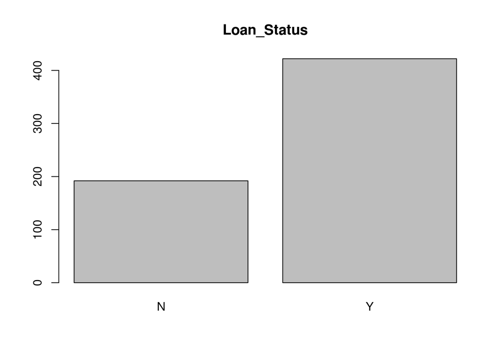

```r
barplot(table(train_data$Loan_Status),main= "Loan_Status")
```

Lets’s Explore our Independent variables-  
1. Gender

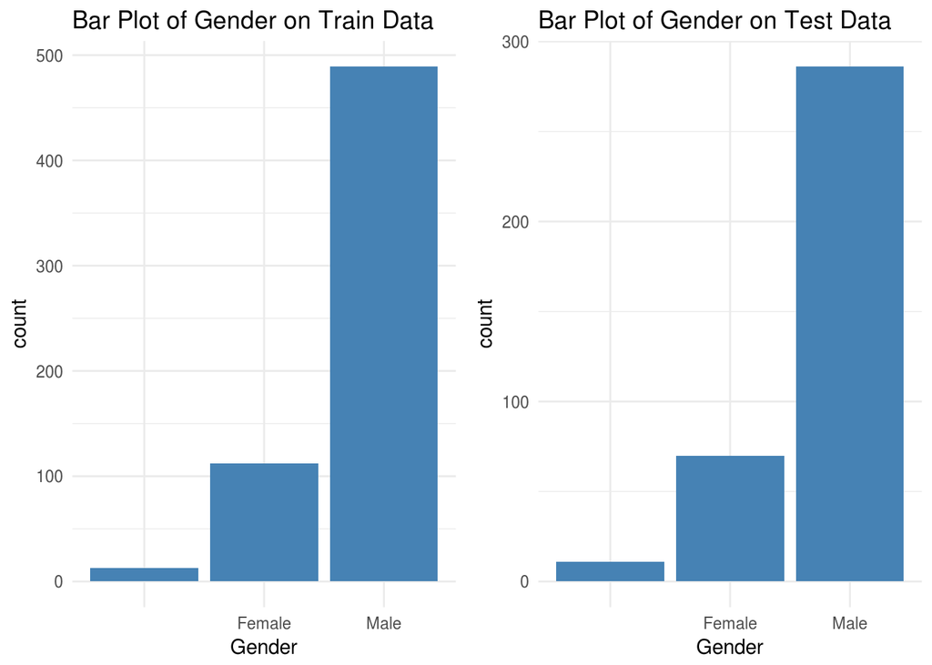

```r
plot1 <- ggplot(data=train_data, aes(train_data$Gender))+geom_bar(fill="steelblue")+theme_minimal()+labs(x = "Gender")+labs(title="Bar Plot of Gender on Train Data")
plot2 <- ggplot(data=test_data, aes(test_data$Gender))+geom_bar(fill="steelblue")+theme_minimal()+labs(x = "Gender")+labs(title="Bar Plot of Gender on Test Data")
grid.arrange(plot1, plot2, nrow=1, ncol=2)
```

2. Married

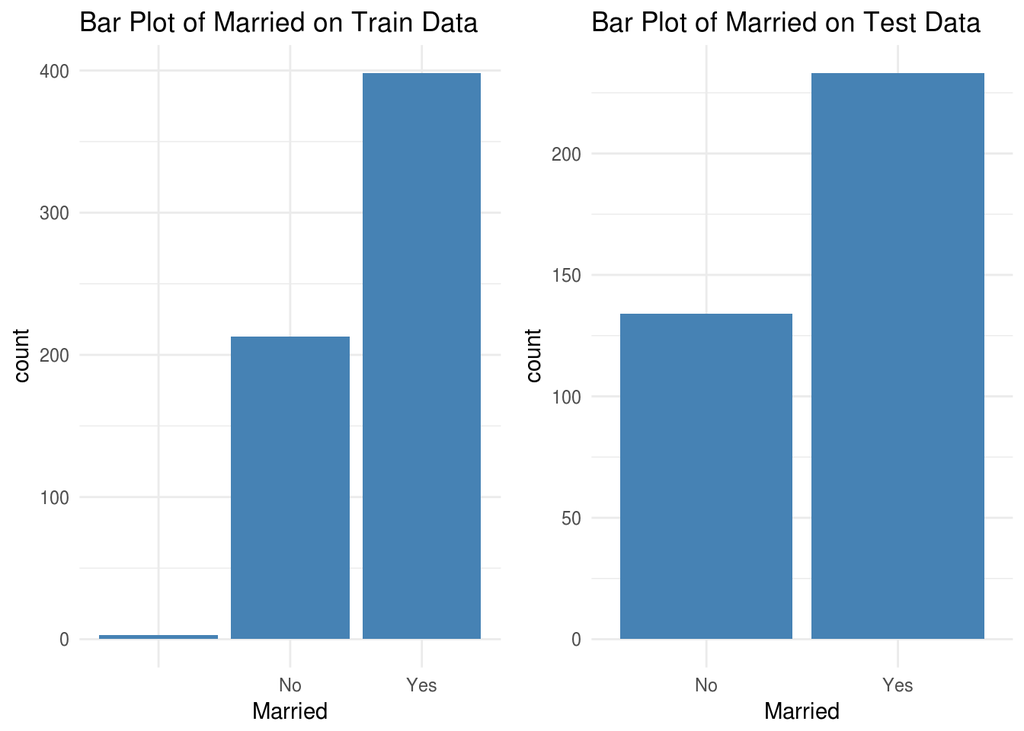

```r
plot1 <- ggplot(data=train_data, aes(train_data$Married))+geom_bar(fill="steelblue")+theme_minimal()+labs(x = "Married")+labs(title="Bar Plot of Married on Train Data")
plot2 <- ggplot(data=test_data, aes(test_data$Married))+geom_bar(fill="steelblue")+theme_minimal()+labs(x = "Married")+labs(title="Bar Plot of Married on Test Data")
grid.arrange(plot1, plot2, nrow=1, ncol=2)
```

3. Dependents

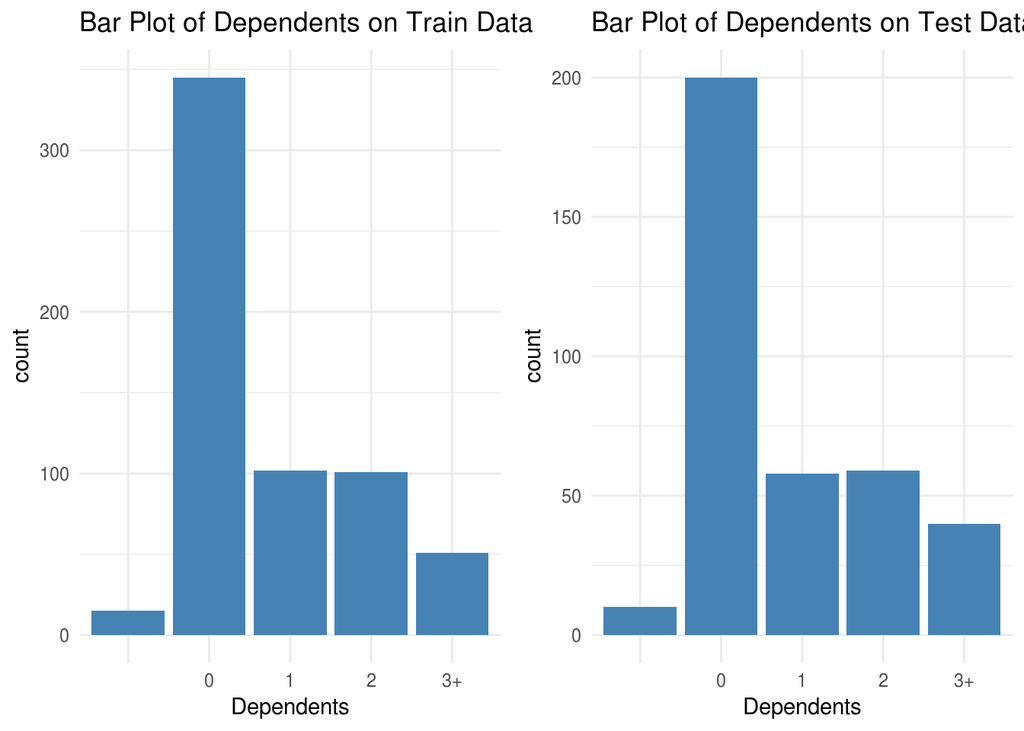

```r
plot1 <- ggplot(data=train_data, aes(train_data$Dependents))+geom_bar(fill="steelblue")+theme_minimal()+labs(x = "Dependents")+labs(title="Bar Plot of Dependents on Train Data")
plot2 <- ggplot(data=test_data, aes(test_data$Dependents))+geom_bar(fill="steelblue")+theme_minimal()+labs(x = "Dependents")+labs(title="Bar Plot of Dependents on Test Data")
grid.arrange(plot1, plot2, nrow=1, ncol=2)
```

4. Education

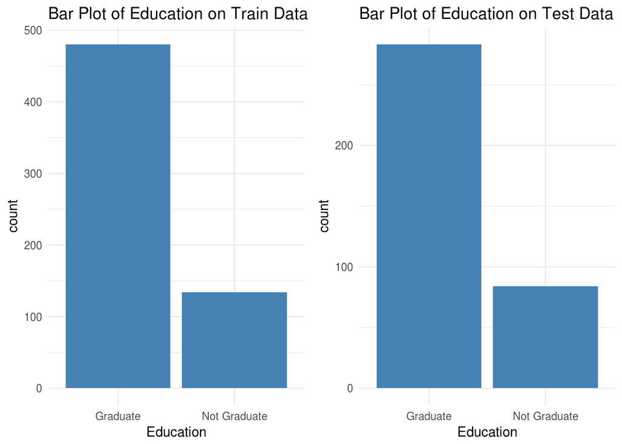

```r
plot1 <- ggplot(data=train_data, aes(train_data$Education))+geom_bar(fill="steelblue")+theme_minimal()+labs(x = "Education")+labs(title="Bar Plot of Education on Train Data")
plot2 <- ggplot(data=test_data, aes(test_data$Education))+geom_bar(fill="steelblue")+theme_minimal()+labs(x = "Education")+labs(title="Bar Plot of Education on Test Data")
grid.arrange(plot1, plot2, nrow=1, ncol=2)
```

5. Self_Employed

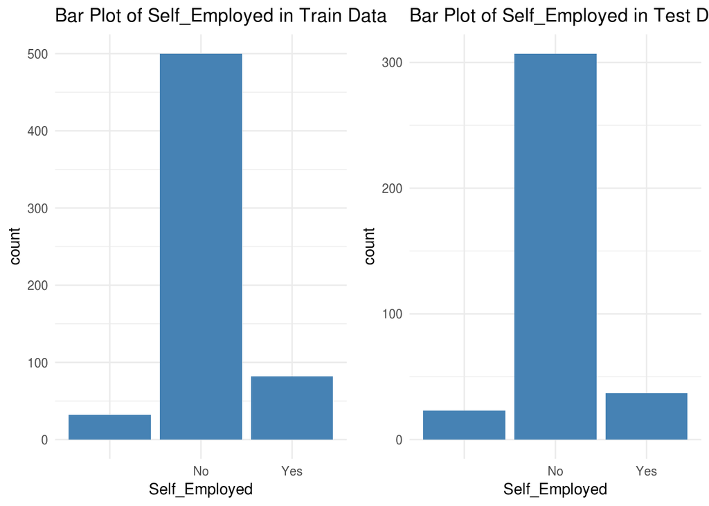

```r
plot1 <- ggplot(data=train_data, aes(train_data$Self_Employed))+geom_bar(fill="steelblue")+theme_minimal()+labs(x = "Self_Employed")+labs(title="Bar Plot of Self_Employed in Train Data")
plot2 <- ggplot(data=test_data, aes(test_data$Self_Employed))+geom_bar(fill="steelblue")+theme_minimal()+labs(x = "Self_Employed")+labs(title="Bar Plot of Self_Employed in Test Data")
grid.arrange(plot1, plot2, nrow=1, ncol=2)
```

6. ApplicantIncome (Numeric) & CoapplicantIncome (Numeric)

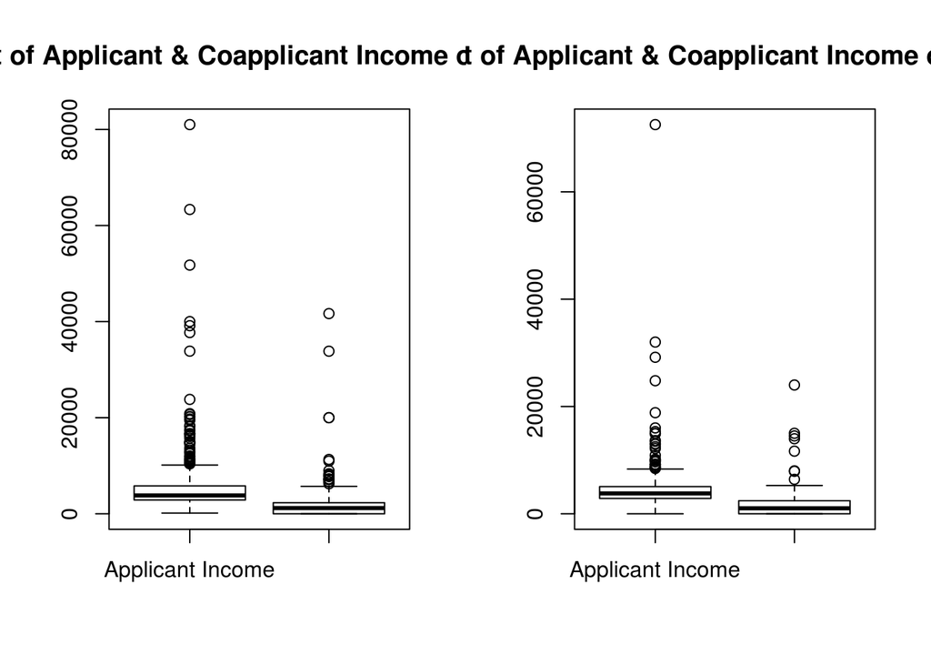

```r
par(mfrow=c(1,2))
boxplot(train_data$ApplicantIncome,train_data$CoapplicantIncome,names=c("Applicant Income","Coapplicant Income"),main="Box Plot of Applicant & Coapplicant Income on Train Data")
boxplot(test_data$ApplicantIncome,test_data$CoapplicantIncome,names=c("Applicant Income","Coapplicant Income"),main="Box Plot of Applicant & Coapplicant Income on Test Data")
```

8. LoanAmount (Numeric)

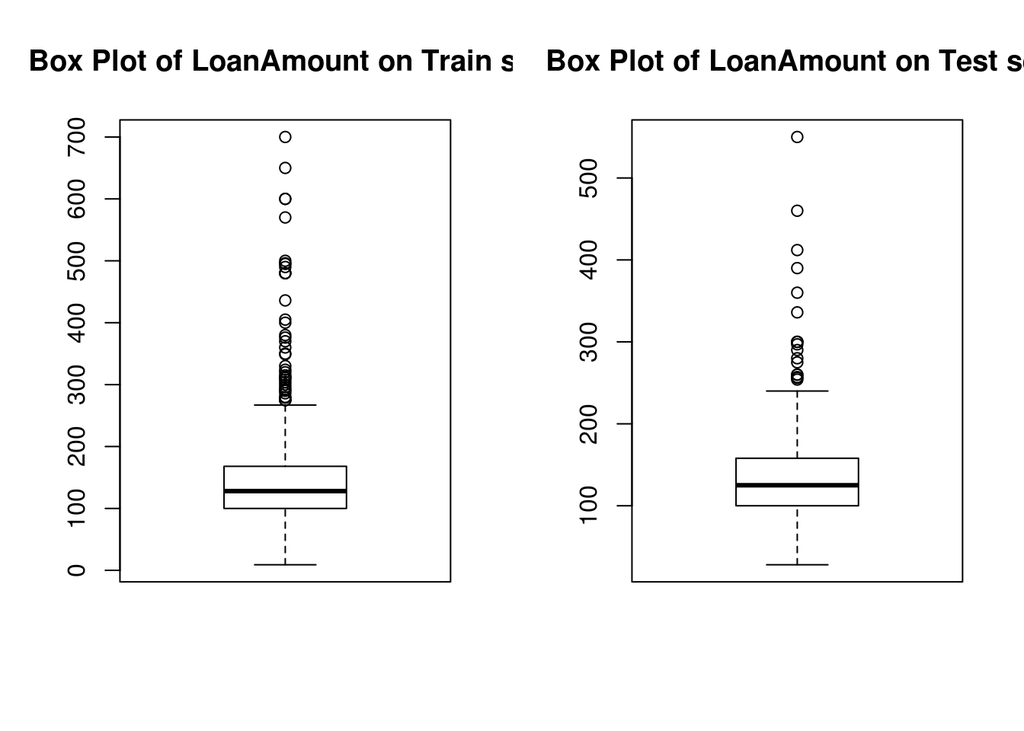

```r
par(mfrow=c(1,2))
boxplot(train_data$LoanAmount,main="Box Plot of LoanAmount on Train set")
boxplot(test_data$LoanAmount,main="Box Plot of LoanAmount on Test set")
```

9. Loan_Amount_Term (Numeric)

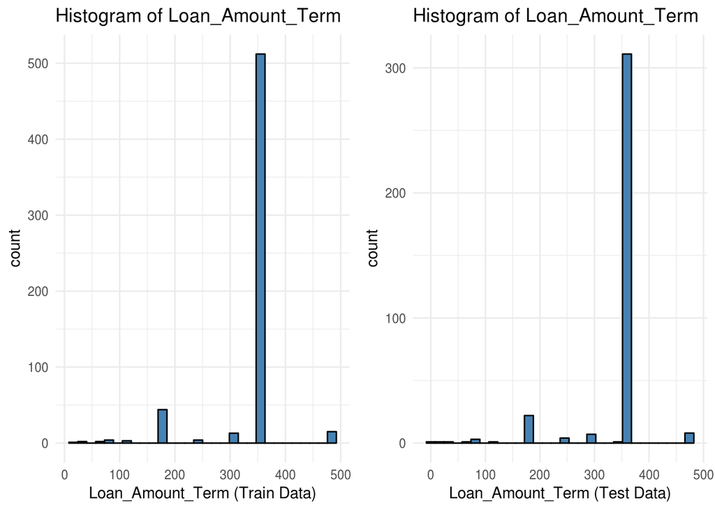

```r
plot1 <- ggplot(data=train_data, aes(train_data$Loan_Amount_Term))+geom_histogram(col="black",fill="steelblue",alpha=1)+theme_minimal()+labs(x = "Loan_Amount_Term (Train Data)")+labs(title= "Histogram of Loan_Amount_Term")
plot2 <- ggplot(data=test_data, aes(test_data$Loan_Amount_Term))+geom_histogram(col="black",fill="steelblue",alpha=1)+theme_minimal()+labs(x = "Loan_Amount_Term (Test Data)")+labs(title= "Histogram of Loan_Amount_Term")
grid.arrange(plot1, plot2, nrow=1, ncol=2)
```

10. Credit_History (Factor)

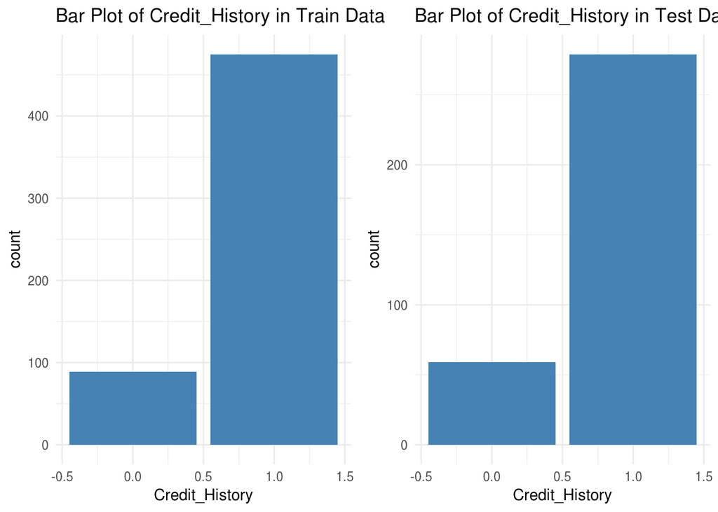

```r
plot1 <- ggplot(data=train_data, aes(train_data$Credit_History))+geom_bar(fill="steelblue")+theme_minimal()+labs(x = "Credit_History")+labs(title="Bar Plot of Credit_History in Train Data")
plot2 <- ggplot(data=test_data, aes(test_data$Credit_History))+geom_bar(fill="steelblue")+theme_minimal()+labs(x = "Credit_History")+labs(title="Bar Plot of Credit_History in Test Data")
grid.arrange(plot1, plot2, nrow=1, ncol=2)
```

11. Property_Area

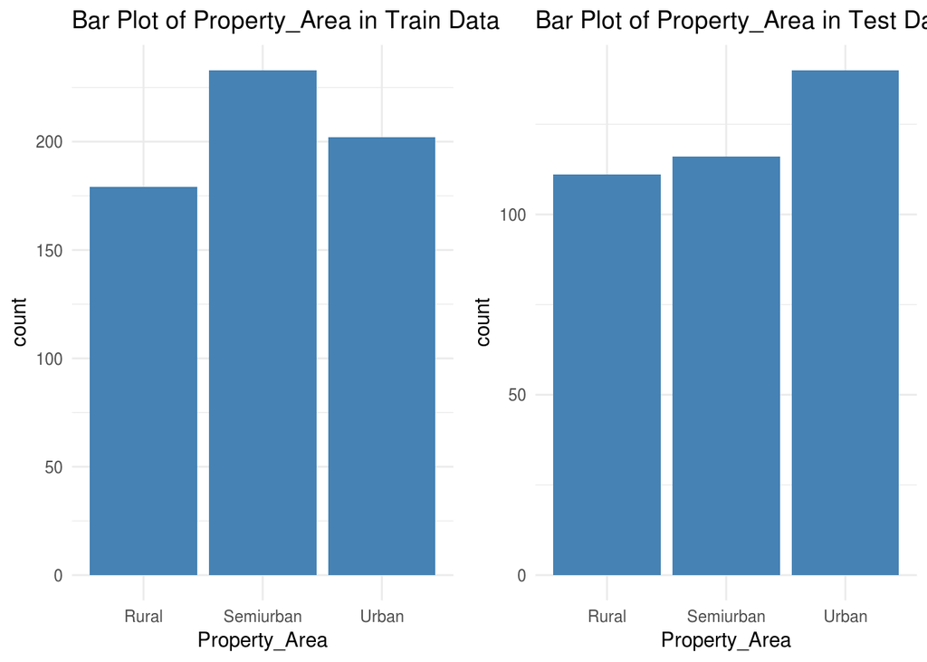

```r
plot1 <- ggplot(data=train_data, aes(train_data$Property_Area))+geom_bar(fill="steelblue")+theme_minimal()+labs(x = "Property_Area")+labs(title="Bar Plot of Property_Area in Train Data")
plot2 <- ggplot(data=test_data, aes(test_data$Property_Area))+geom_bar(fill="steelblue")+theme_minimal()+labs(x = "Property_Area")+labs(title="Bar Plot of Property_Area in Test Data")
grid.arrange(plot1, plot2, nrow=1, ncol=2)
```

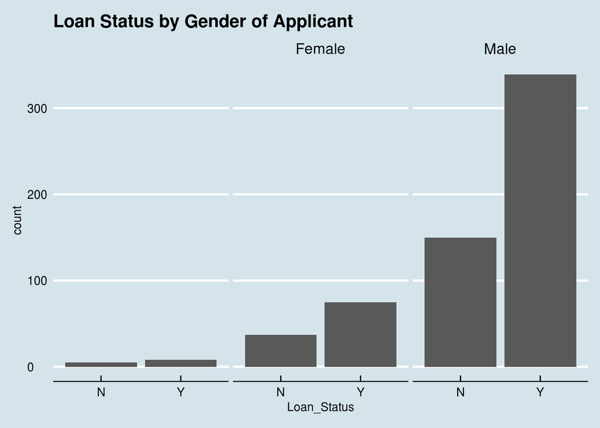

```r
theme_set(theme_economist())
print(ggplot(train_data, aes(x=Loan_Status))+geom_bar()+facet_grid(.~Gender)+ggtitle("Loan Status by Gender of Applicant"))
```

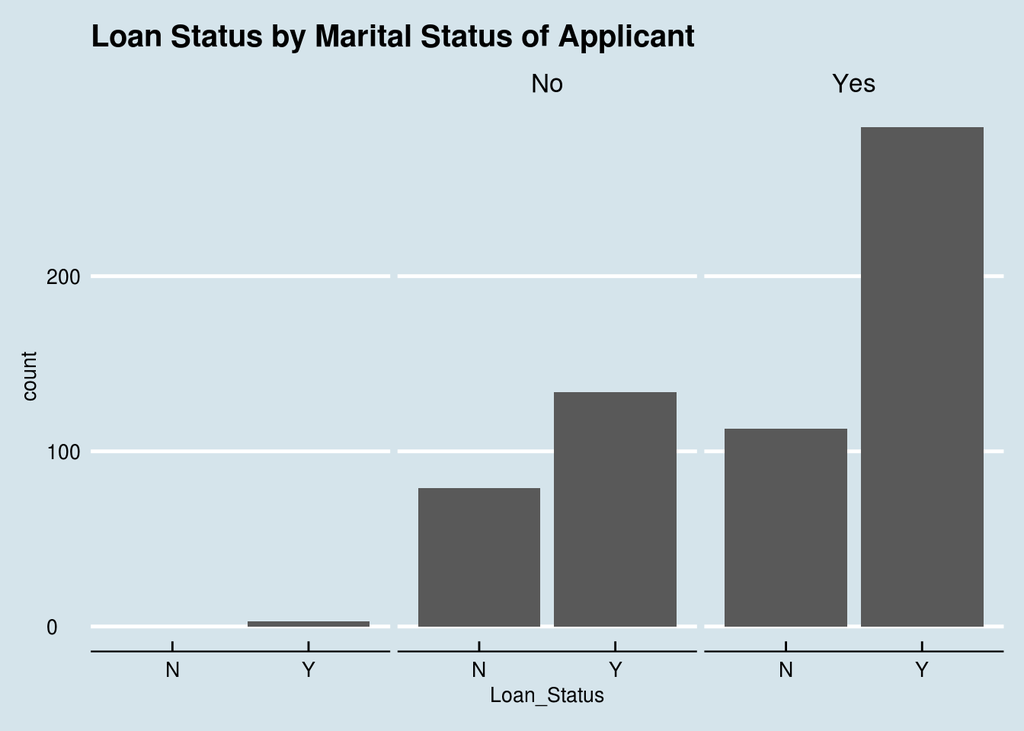

```r
print(ggplot(train_data, aes(x=Loan_Status))+geom_bar()+facet_grid(.~Married)+ggtitle("Loan Status by Marital Status of Applicant"))
```

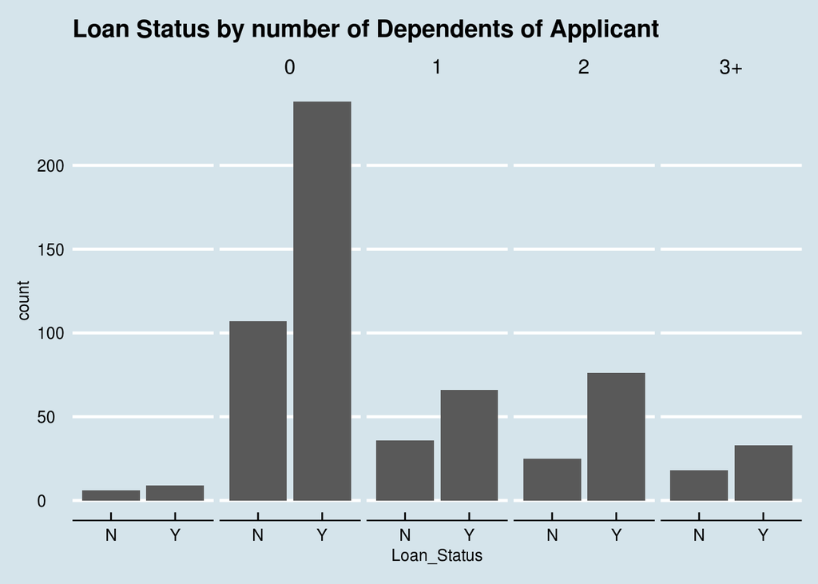

```r
print(ggplot(train_data, aes(x=Loan_Status))+geom_bar()+facet_grid(.~Dependents)+ggtitle("Loan Status by number of Dependents of Applicant"))
```

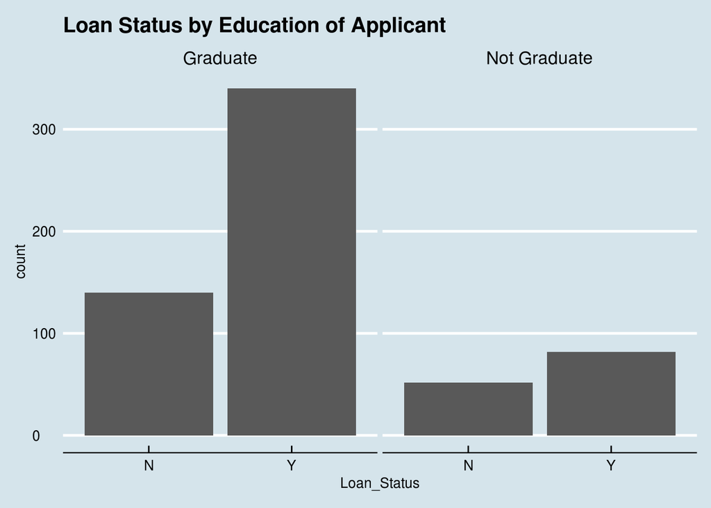

```r
print(ggplot(train_data, aes(x=Loan_Status))+geom_bar()+facet_grid(.~Education)+ggtitle("Loan Status by Education of Applicant"))
```

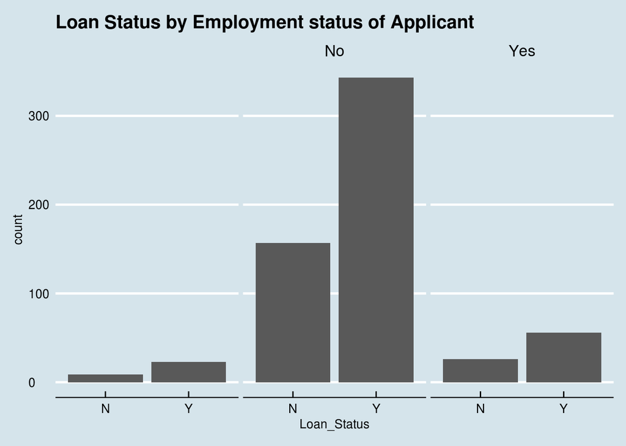

```r
print(ggplot(train_data, aes(x=Loan_Status))+geom_bar()+facet_grid(.~Self_Employed)+ggtitle("Loan Status by Employment status of Applicant"))
```

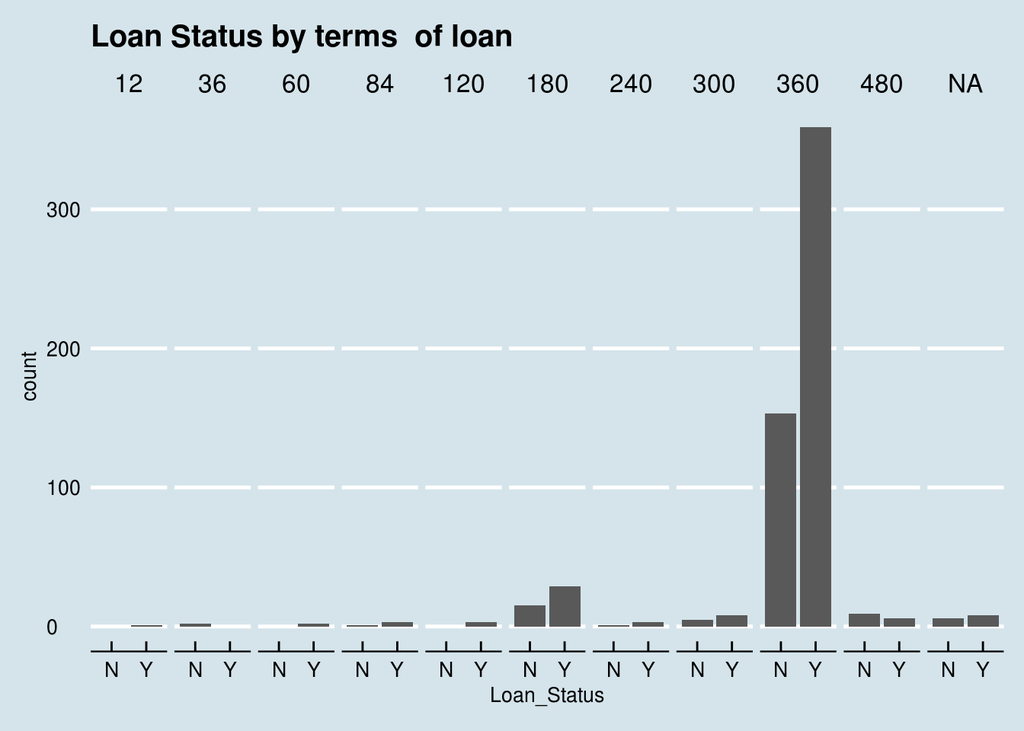

```r
print(ggplot(train_data, aes(x=Loan_Status))+geom_bar()+facet_grid(.~Loan_Amount_Term)+ggtitle("Loan Status by terms  of loan"))
```

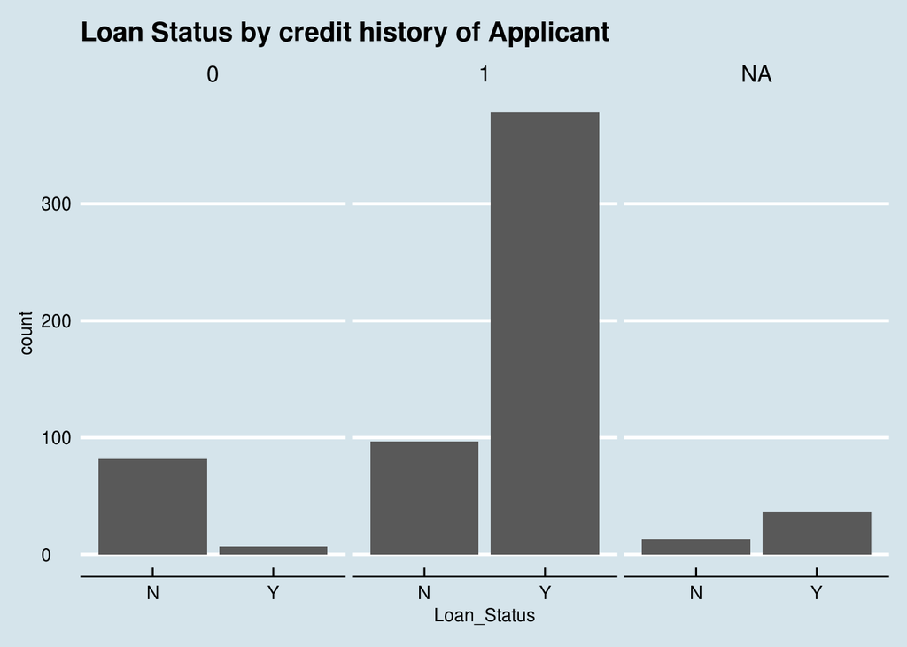

```r
print(ggplot(train_data, aes(x=Loan_Status))+geom_bar()+facet_grid(.~Credit_History)+ggtitle("Loan Status by credit history of Applicant"))
```

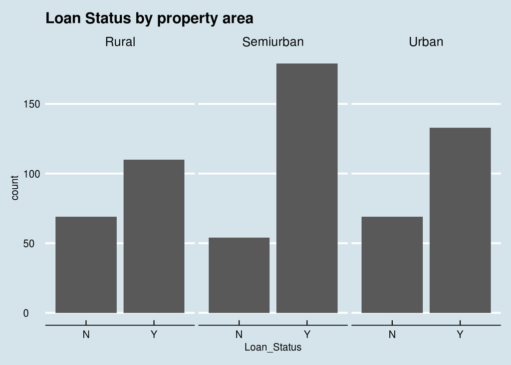

```r
print(ggplot(train_data, aes(x=Loan_Status))+geom_bar()+facet_grid(.~Property_Area)+ggtitle("Loan Status by property area"))
```

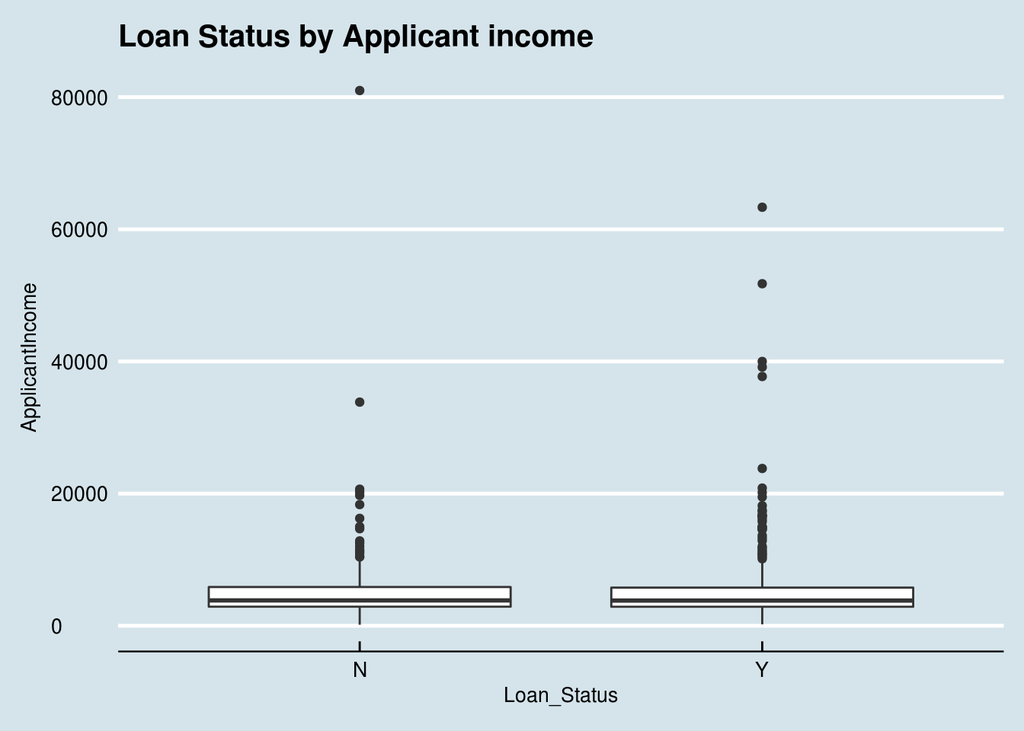

```r
print(ggplot(train_data, aes(x=Loan_Status,y=ApplicantIncome))+geom_boxplot()+ggtitle("Loan Status by Applicant income"))
```

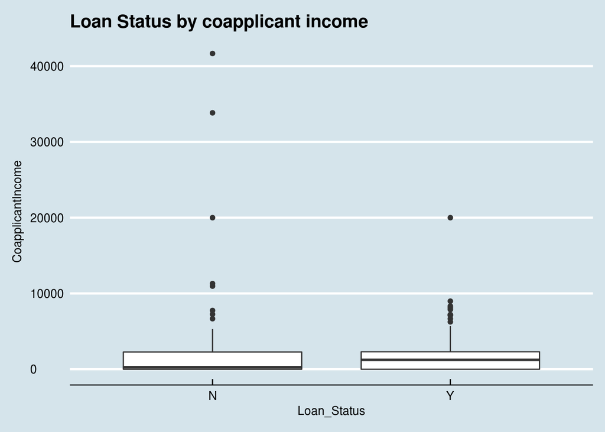

```r
print(ggplot(train_data, aes(x=Loan_Status,y=CoapplicantIncome))+geom_boxplot()+ggtitle("Loan Status by coapplicant income"))
```

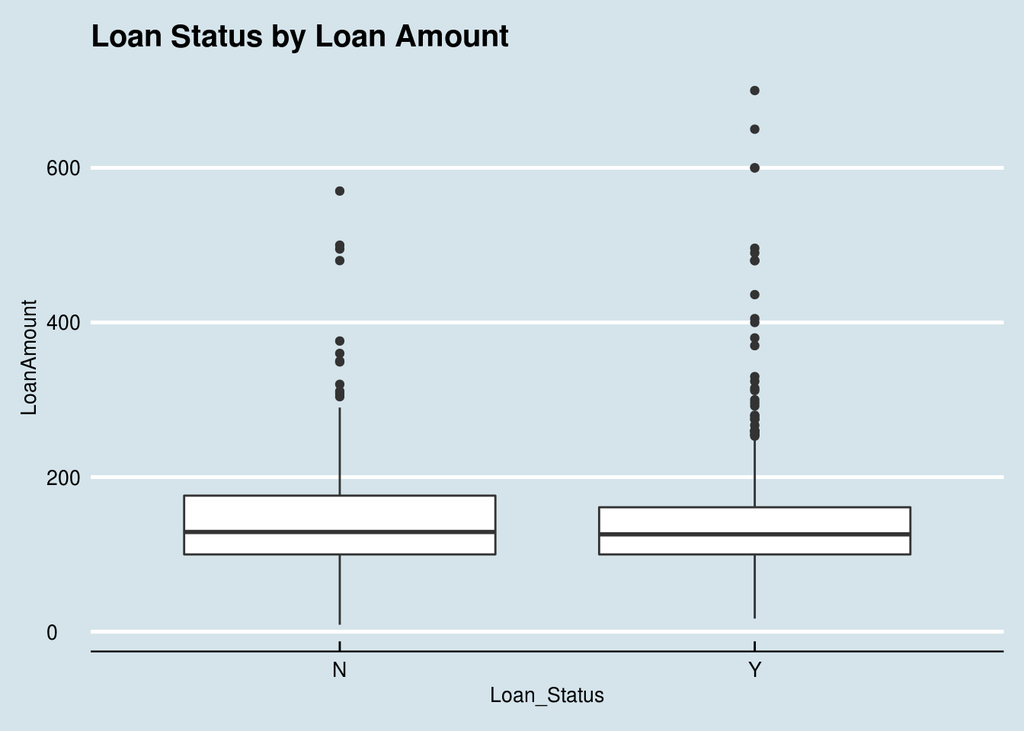

```r
print(ggplot(train_data, aes(x=Loan_Status,y=LoanAmount))+geom_boxplot()+ggtitle("Loan Status by Loan Amount"))
```

** Filling NA values** 1. Usually while applying for loan total family income is calculated So we can add Applicant and Co_Applicant income, but before that we need to combine our dataset

```r
Complete_Data <- rbind(train_data[,2:12],test_data[,2:12])
Complete_Data <- mutate(Complete_Data,TotalIncome=ApplicantIncome+CoapplicantIncome)
```

When there is “No” co-applicant income assuming as Unmarried and Married otherwise

```r
Complete_Data$Gender <- as.character(Complete_Data$Gender)
Complete_Data$Married <- as.character(Complete_Data$Married)
Complete_Data$Self_Employed <- as.character(Complete_Data$Self_Employed)
Complete_Data$Married[Complete_Data$Married=="" & Complete_Data$CoapplicantIncome==0]<-"No"
Complete_Data$Married[Complete_Data$Married==""]<- "Yes"
```

```r
Complete_Data$Dependents <- as.character(Complete_Data$Dependents)
Complete_Data$Gender[Complete_Data$Gender=="" & Complete_Data$Dependents==""] <- "Male"
```

When Dependents is unknown but not married then assuming no dependents

```r
Complete_Data$Dependents[Complete_Data$Dependents=="" & Complete_Data$Married=="No"]<- "0"
```

Most of the loan term is 360, so filling NA as 360 in loan amount and renaming 350 as 360 and 6 as 60 since their feq is low and m,ight be due to tying error while entering data

```r
Complete_Data$Loan_Amount_Term[is.na(Complete_Data$Loan_Amount_Term)]<-"360"
library(car)
Complete_Data$Loan_Amount_Term <- recode(Complete_Data$Loan_Amount_Term,"'350'='360';'6'='60'")
```

Assuming “” empty factor in self employed. As most are not self employed

```r
Complete_Data$Self_Employed[Complete_Data$Self_Employed==""] <- "No"
```

Assuming person with no credit history as another catrgory

```r
Complete_Data$Credit_History<-recode(Complete_Data$Credit_History,"NA=2")
Complete_Data$Gender <- as.factor(Complete_Data$Gender)
Complete_Data$Married <- as.factor(Complete_Data$Married)
Complete_Data$Dependents <- as.factor(Complete_Data$Dependents)
Complete_Data$Self_Employed <- as.factor(Complete_Data$Self_Employed)
Complete_Data$Loan_Amount_Term <- as.factor(Complete_Data$Loan_Amount_Term)
```

To predict Remaining Gender by (Mode Imputation) & Dependents

```r
levels(Complete_Data$Gender)[levels(Complete_Data$Gender)==""] <- "Male"
levels(Complete_Data$Dependents)[levels(Complete_Data$Dependents)==""] <- "0"
```

We will predict Loan Amount using K-Nearrest neighbours

```r
preProcValues <- preProcess(Complete_Data, method = c("knnImpute","center","scale"))
Complete_data_processed <- predict(preProcValues, Complete_Data)
```

Splitting Training and Test Data set back

```r
trainSet <- Complete_data_processed[ 1:614,]
trainSet$Loan_Status <- train_data$Loan_Status
testSet <- Complete_data_processed[615:981,]
```

Creating Train control

```r
fitControl <- trainControl(method = "cv", number = 7, savePredictions = 'final', classProbs = T)
```

Creating Random Forest

```r
#Training the random forest model
model_rf<-train(Loan_Status~.,data=trainSet,method='rf',trControl=fitControl,tuneLength=3)
#Predicting using random forest model
testSet$pred_rf<-predict(object = model_rf,testSet[,-13])
```

This was the uploaded to kaggle and output accuracy was 81.1% after tuning random forest.